# RR_Week4_Assignment_on_StormData

Bishnu Poudel

March 21, 2019

### Including the preprocessing steps as commented R Scripts

### Preprocessing: Download the file,read the csv,then dump un-necessary columns

```r
# #Download file -- Uncomments
# setwd("../DATA_SCIENCE_COURSERA/Reproducible Research/Week4/")
# download.file("https://d396qusza40orc.cloudfront.net/repdata%2Fdata%2FStormData.csv.bz2"
#               , destfile="Stormdata.csv.dz2", method="libcurl")
# data<- read.csv("Stormdata.csv")
#
# #Strip out unnecessay columns and write to to different .csv if needed
# #I've under 2GB ram in my system.
# names_loc_out<- c("COUNTY","COUNTYNAME","STATE","LATITUDE","LONGITUDE","LATITUDE_E","LONGITUDE_","REFNUM")
# names_rem_out<-  c( "STATEOFFIC","ZONENAMES", "REMARKS","REFNUM" )
# names_loc_del<- c("COUNTYNAME","STATE","LATITUDE","LONGITUDE"
#                   ,"LATITUDE_E","LONGITUDE_", "STATEOFFIC","ZONENAMES", "REMARKS")
# addressdim<- data[names_loc_out]
# remarks<-data[names_rem_out]
# df<- data[, !(colnames(data) %in% names_loc_del)  ]
# write.csv(addressdim, file="AddressDim.csv")
# write.csv(remarks, file="Remarks.csv")
# rm(data)
```

From findings of initial EDA, the following columns give the crux of the information for addressing our questions on - The event with most fatalities/injuries - The event with most economic consequences. 1. FATALITIES 2. INJURIES 3. PROPDMG , PROPDMGEXP (k,m,b,h) 4. CROPDMG,CROPDMGEXP(k,m,b,h)

### Adding one of the EDAs I did which was crucial for finding the granularity of the data

#### First , we investigate the duplicate on BGN_DATE, COUNTY, EVTYPE

```r
# Task 1 - Find what the database is unique on (i.e. primary Key)
# Also exploring data on my Own

#Comment this read part if the above chunk is not run
df<- read.csv("stripped.csv")
dim(df)  # [1] 902297 28
```

```
## [1] 902297     29
```

```r
# dim( unique( df[c("BGN_DATE","COUNTY","EVTYPE")] ) )   ##[1] 570401  3
# dim( unique( df[c("BGN_DATE","BGN_TIME", "COUNTY","EVTYPE")] )) ##871125 4
# dim( unique( df[c( "STATEID", "BGN_DATE","BGN_TIME", "COUNTY","EVTYPE")] ) ) ##[1] 873837 5
library(sqldf)
#duplicates on 3 variables
dups<- sqldf(" select BGN_DATE, COUNTY, EVTYPE, count(*) as counts from df group by 1,2,3 having count(*) >1 ")
#max(dups$counts)
#dups[dups$counts==125, ]
dup125<- df[ df$BGN_DATE=="11/11/1995 0:00:00" & df$COUNTY==0 & df$EVTYPE=="HIGH WINDS" , ]
#View(head(dup125))
```

```r
#duplicates on 5 variables
library(sqldf)
names(df)[names(df)=="STATE__"]<- "STATEID"
dups<- sqldf(" select STATEID, BGN_DATE,  COUNTY, EVTYPE, count(*) as counts from df group by 1,2,3 having count(*) >1 ")
#max(dups$counts)
#dups[dups$counts==72, ]
dup125<- df[ df$BGN_DATE=="11/11/1995 0:00:00" & df$COUNTY==0 & df$EVTYPE=="HIGH WINDS" & df$STATEID==51 , ]
#View(head(dup125))
```

## Adding further self explanatory data cleaning and summarising steps

We carried out 3 main data tidying steps

1. Convert the dates to actual date format, also extract just the year part
2. Convert the damage amounts to actual dollar amounts
3. Sum up the damage and casualties by day, year and finally only on the event type. We use only the roll-up by event-type. Have excluded other roll-ups.

```r
#Using sqldf as it brings the results in tabular format by default
library(sqldf)
library(lubridate)
# A new date column added for futher processing
df$DATE<- as.Date( as.character( df$BGN_DATE  ) ,"%m/%d/%Y" )

#The property damage and crop damage COSTS need further processing.
df$CROP_DOL<- as.numeric( 0)
df$PROP_DOL<- as.numeric( 0)
    #Now give them values accordingly, B, M and K

df[df$CROPDMGEXP %in% c("B","b"),]$CROP_DOL <- df[df$CROPDMGEXP %in% c("B","b"),]$CROPDMG*1000000000
df[df$CROPDMGEXP %in% c("M","m"),]$CROP_DOL <- df[df$CROPDMGEXP %in% c("M","m"),]$CROPDMG*1000000
df[df$CROPDMGEXP %in% c("K","k"),]$CROP_DOL <- df[df$CROPDMGEXP %in% c("K","k"),]$CROPDMG*1000
df[df$CROPDMGEXP %in% c("H","h"),]$CROP_DOL <- df[df$CROPDMGEXP %in% c("H","h"),]$CROPDMG*100
df[ !(df$CROPDMGEXP %in% c("H","h","M","m","K","k","B","b") ),]$CROP_DOL <- df[!(df$CROPDMGEXP %in% c("H","h","M","m","K","k","B","b") ),]$CROPDMG

df[df$PROPDMGEXP %in% c("B","b"),]$PROP_DOL <- df[df$PROPDMGEXP %in% c("B","b"),]$PROPDMG*1000000000
df[df$PROPDMGEXP %in% c("M","m"),]$PROP_DOL <- df[df$PROPDMGEXP %in% c("M","m"),]$PROPDMG*1000000
df[df$PROPDMGEXP %in% c("K","k"),]$PROP_DOL <- df[df$PROPDMGEXP %in% c("K","k"),]$PROPDMG*1000
df[df$PROPDMGEXP %in% c("H","h"),]$PROP_DOL <- df[df$PROPDMGEXP %in% c("H","h"),]$PROPDMG*100
df[ !(df$PROPDMGEXP %in% c("H","h","M","m","K","k","B","b") ),]$PROP_DOL <- df[!(df$PROPDMGEXP %in% c("H","h","M","m","K","k","B","b") ),]$PROPDMG

#Now we can summarise in dollar amount by event type and event date (not by date here)
df$YEAR<- year(df$DATE)
df$EVTYPE<- tolower(trimws(df$EVTYPE, which="both"  ) )
sum_evtype<- sqldf("select EVTYPE
                ,sum(FATALITIES) as FATALITIES
                   ,sum(INJURIES) as INJURIES
                   , sum(PROP_DOL) as PROP_DOL
                   , sum(CROP_DOL)  as CROP_DOL
                   from df group by 1  ")
rm(df) #remove the big data frame
```

### put these into the same category

We do the following here

1. Remove invalid event types ( events which are actually Summaries)
2. Build a WordCloud based on the extent of life and property damage separately.

# ### WordCloud for Loss of Lives and Injuries

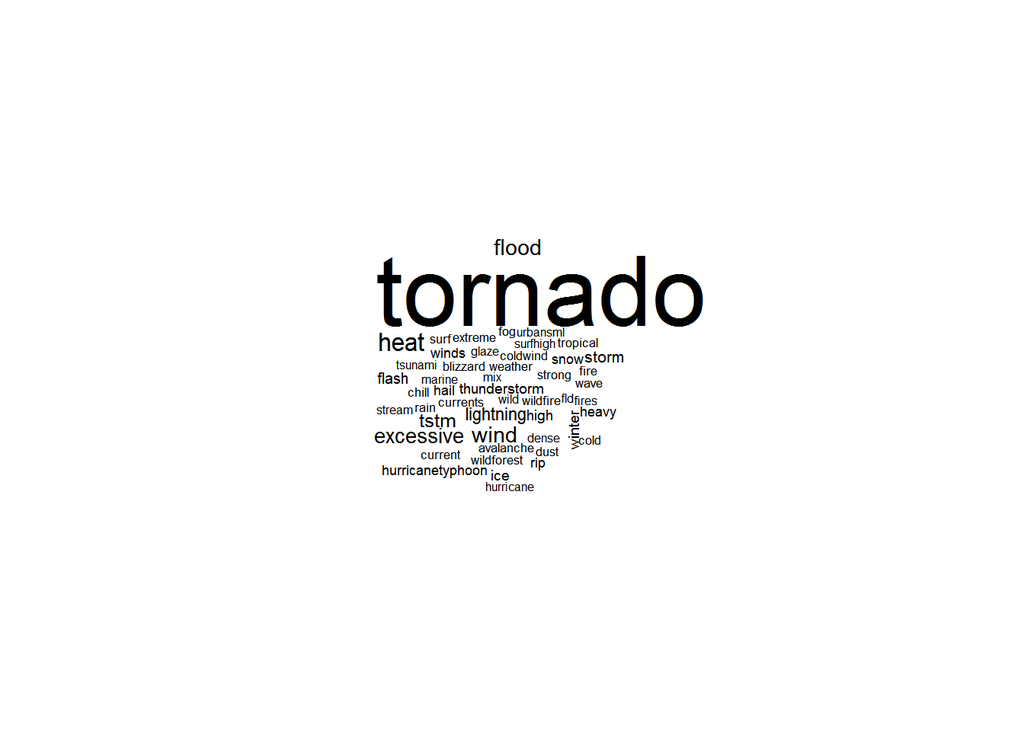

```r
#1. Remove the rows with 'summary' in them in the EVTYPE column
source("cleancorpus.R")
source("tm_wc.R")
valid_ev<- sum_evtype[ which( !grepl("summary", sum_evtype$EVTYPE) ) , ]
#2.get the character collection in a character vector; formulae is repeatition
charcol<- rep(valid_ev$EVTYPE, valid_ev$FATALITIES +( valid_ev$INJURIES*0.5 )   )
tm_wc(charcol)
```

# ### WordCloud for Crop and Property Damage

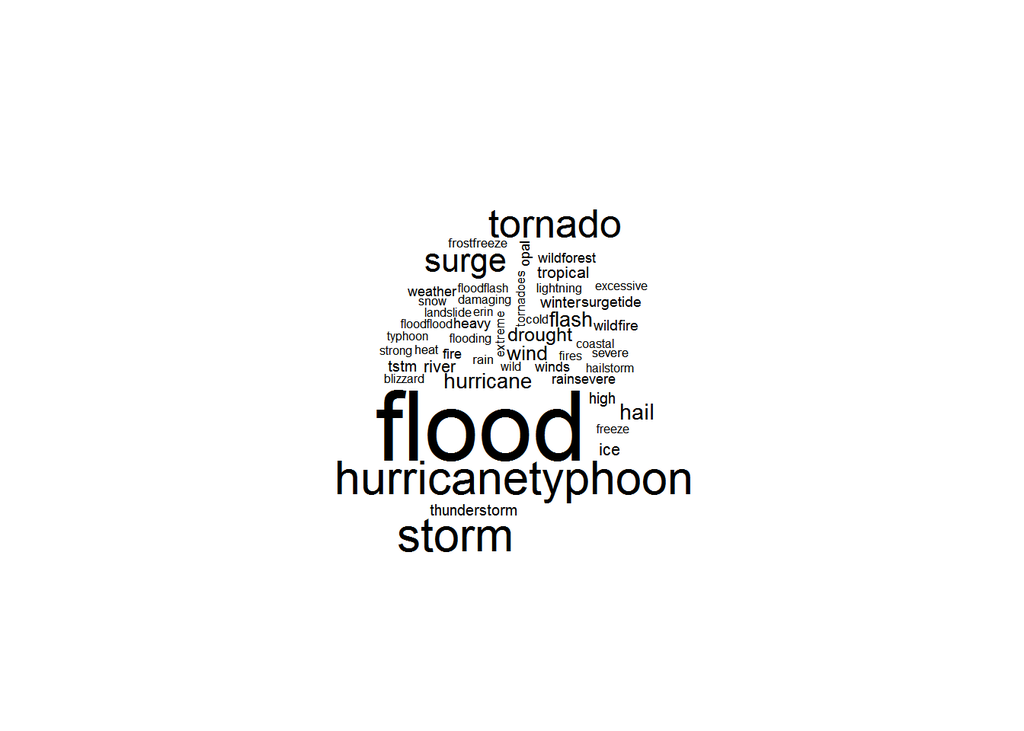

```r
#3. get the same for Property and Crop damage
charcol<- rep(valid_ev$EVTYPE, 1/10000000*( valid_ev$CROP_DOL + valid_ev$PROP_DOL)   )
tm_wc(charcol)
```

## Conclusion: Tornadoes takes the most lives and Floods cause the most property damage!!

# ### Appendix: Also adding in the r functions used above

```r
tm_wc <- function(charcol){
library(tm)
library(stringi)
library(wordcloud)
col<- SimpleCorpus( VectorSource(charcol) )
#run cleaning
source("cleancorpus.R")
col<- cleancorpus(col)
dtm <- DocumentTermMatrix(col)
dtm2 <- as.matrix(dtm)
frequency <- colSums(dtm2)
frequency <- sort(frequency, decreasing=TRUE)
##names(frequency)

#Now use the frequency to make a WORDCLOUD
freqdf<- data.frame( occur=frequency , word= names(frequency))
rownames(freqdf)<-NULL
wordcloud(word=freqdf$word, freq=freqdf$occur, max.words=50 )
}
```

```r
cleancorpus <- function(corpus){
    library(tm)
    library(stringi)

    corpus <- tm_map(corpus, removePunctuation)
    corpus <- tm_map(corpus, content_transformer(tolower))
    corpus <- tm_map(corpus, removeWords, stopwords("en"))
    corpus<- tm_map(corpus, function(x) gsub( "/", " ", gsub( "\\\\", " ", x) ) )
    corpus <- tm_map(corpus, stripWhitespace)
    return(corpus)
}
```